# Analyzing AB test data

ShoeFly.com is performing an A/B Test. They have two different versions of an ad, which they have placed in emails, as well as in banner ads on Facebook, Twitter, and Google. They want to know how the two ads are performing on each of the different platforms on each day of the week.

```python
import pandas as pd
import numpy as np
import matplotlib.pyplot as plt
import seaborn as sns
import plotly.graph_objs as go
import plotly.offline as py
py.init_notebook_mode(connected=True) # Have to initialize to view plots in notebook
import cufflinks as cf
cf.go_offline()
```

### Loading and veiwing data

```python
clicks = pd.read_excel('Shoefly AB test.xlsx')
```

```python
clicks.head()
```

|  | user_id | utm_source | day | ad_click_timestamp | group |
| --- | --- | --- | --- | --- | --- |
| 0 | 008b7c6c-7272-471e-b90e-930d548bd8d7 | google | 6 - Saturday | 07:18:00 | A |
| 1 | 009abb94-5e14-4b6c-bb1c-4f4df7aa7557 | facebook | 7 - Sunday | NaN | B |
| 2 | 00f5d532-ed58-4570-b6d2-768df5f41aed | twitter | 2 - Tuesday | NaN | A |
| 3 | 011adc64-0f44-4fd9-a0bb-f1506d2ad439 | google | 2 - Tuesday | NaN | B |
| 4 | 012137e6-7ae7-4649-af68-205b4702169c | facebook | 7 - Sunday | NaN | B |

```python
clicks.describe() # exploring summary stats
```

|  | user_id | utm_source | day | ad_click_timestamp | group |
| --- | --- | --- | --- | --- | --- |
| count | 1654 | 1654 | 1654 | 565 | 1654 |
| unique | 1654 | 4 | 7 | 464 | 2 |
| top | 7594e8f3-4c85-4a74-bdc2-8343318bc0df | google | 5 - Friday | 09:18:00 | B |
| freq | 1 | 680 | 256 | 4 | 827 |

```python
clicks.info()
```

```
<class 'pandas.core.frame.DataFrame'>
RangeIndex: 1654 entries, 0 to 1653
Data columns (total 5 columns):
user_id               1654 non-null object
utm_source            1654 non-null object
day                   1654 non-null object
ad_click_timestamp    565 non-null object
group                 1654 non-null object
dtypes: object(5)
memory usage: 64.7+ KB
```

Null values in `ad_click_timestamp column` means that the ad was not clicked. The data is clean and we can proceed to analysis.

### Clicks by source

```python
# Adding new column is_click to represent whether or not the ad was clicked.
clicks['is_click'] =clicks.ad_click_timestamp.notnull()
```

```python
# Statistics by source
total_views = clicks.utm_source.value_counts()
total_clicks = clicks.groupby('utm_source').sum().astype(int)
percentage_clicks= clicks.groupby('utm_source').mean()
clicks_source = pd.concat([total_clicks,total_views,percentage_clicks],axis=1,sort=False) # joining dataframes into one
clicks_source.columns=['total_clicks','total_views','percentage_clicks'] #renaming colum
clicks_source
```

|  | total_clicks | total_views | percentage_clicks |
| --- | --- | --- | --- |
| email | 80 | 255 | 0.313725 |
| facebook | 180 | 504 | 0.357143 |
| google | 239 | 680 | 0.351471 |
| twitter | 66 | 215 | 0.306977 |

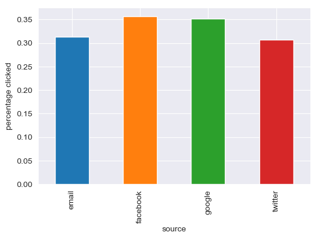

```python
sns.set_style('darkgrid')
fig,ax=plt.subplots(dpi=100)
clicks_source.percentage_clicks.plot(kind='bar',ax=ax)
plt.xlabel('source')
plt.ylabel('percentage clicked')
plt.show()
```

### Clicks by group

```python
#Viewing the number of people in each experimental group
clicks.group.value_counts()
```

```
B    827
A    827
Name: group, dtype: int64
```

We note that there are same number of people in both experimental groups

```python
clicks.groupby('group').mean() # click % by group
```

| group | is_click |
| --- | --- |
| A | 0.374849 |
| B | 0.308343 |

**Greater % of people clicked ad A which implies that A performed better than B overall**

```python
# Viewing performance by group and source
df = clicks.groupby(['utm_source','group']).mean().reset_index()
df = df.pivot('utm_source','group','is_click')
```

```python
df
```

| group utm_source | A | B |
| --- | --- | --- |
| email | 0.338843 | 0.291045 |
| facebook | 0.370079 | 0.344000 |
| google | 0.392550 | 0.308157 |
| twitter | 0.368932 | 0.250000 |

```python
# Visualizing the above table
df.iplot(kind='bar',opacity=0.9,colors=['#41b3a3','#c38d9e'], # bar plot
         xTitle='Source',yTitle='percentage clicked', # x and y axis titles
         bargap=0.4,bargroupgap=0.05) # setting bar gaps
```

[interactive chart not shown]

**A outperforms B in each source and the gap is higher for google and twitter. Both perform similarly in Fcaebook.**

### Clicks by day of week

```python
click_by_day = clicks.groupby(['day','group']).mean().reset_index() # grouping by day of week and experimental group
click_by_day = click_by_day.pivot('day','group','is_click') #pivoting the data
click_by_day
```

| group day | A | B |
| --- | --- | --- |
| 1 - Monday | 0.380531 | 0.283186 |
| 2 - Tuesday | 0.361345 | 0.378151 |
| 3 - Wednesday | 0.306452 | 0.282258 |
| 4 - Thursday | 0.405172 | 0.250000 |
| 5 - Friday | 0.398438 | 0.296875 |
| 6 - Saturday | 0.381356 | 0.355932 |
| 7 - Sunday | 0.394495 | 0.311927 |

#### Interactive plot using pyplot

```python
# x labels for visualization
xlabels = np.asarray(click_by_day.index)
# stripping of the number for day of week. E.g. changing '1- Monday' to 'Monday'
xlabels = [i.split('-')[1] for i in xlabels]
```

```python
layout= go.Layout(title = 'Percentage of clicks by week of day',
                  #setting xaxis label and grid color
                  xaxis=dict(title='Day',gridcolor='white'),
                  #setting yaxis label,grid color and axis range
                  yaxis=dict(title='Percentage Clicked',gridcolor='white',range=[0.2,0.5]),
                  hovermode ='x', # set behaviour when hovering over plot
                  paper_bgcolor='rgb(255,255,255)', #background color for paper
                  plot_bgcolor='#EAEAF1' #background color for plot
                 )

data1 = go.Scatter(x=xlabels,y=click_by_day.A,
                   name='A',
                   mode='lines+markers',
                   marker=dict(size=8,opacity=0.6)
                  )
data2 = go.Scatter(x=xlabels,y=click_by_day.B,name='B',marker=dict(size=8,opacity=0.6))
data= [data1,data2]
fig = go.Figure(data=data,layout=layout)
py.iplot(fig)
```

[interactive chart not shown]

We see that Ad A outperforms B on most days. However, Ad B seems to perform better on Tuesday. Before drawing a conclusion, it is important to look at the time frame for the test as it is likely that the result may not be statistically significant. It is also crucial to perform some qualitative analysis to understand why an Ad would perform better on a certain week day. Unfortunately, we don't have the data for this here and is beyond the scope of our analysis.

### Conclusion

Ad A performs better than Ad B for all sources and most days of the week. The overall click rate of Ad A is 37.5% while Ad B is 31%.Shoefly should proceed with Ad A for all users.